# Teaching

This is a continually updated list of my teaching materials. Unless indicated, all material is released under CC-NonCommercial license. For other uses, please contact me.

## Highlights

- BSTA 504 R Programming - This is a course that I taught at Oregon Health Science University/Portland State University School of Public Health. My colleague, Jessica Minnier still teaches it. It has a number of innovations, including a [tidyverse function of the week assignment](https://sph-r-programming.netlify.app/functions/), and [midterm projects using Tidy Tuesday data](https://sph-midterm-projects.netlify.app/).
- My Ready for R online course teaching the Tidyverse is currently at 1800+ users. This is a self paced course with video lessons, and a Posit Cloud project for doing your work.
- My Books: Bash for Bioinformatics and Best Practices on the DNAnexus Platform are used by users of the UK Biobank Research Analysis platform and our customers on the Core DNAnexus platform
- Video Webinars: Cloud Computing for HPC Users, Gradual Introduction to Shiny showcase my teaching techniques.

### Intermediate Shiny: Drawing the Owl

shiny

workshop

best-practices

free

This workshop aims to get you over the hill to faster, better looking, and dynamic Shiny Apps.

Jun 21, 2024

Ted Laderas

### WebR: Why, What How

WebR

free

View slides in full screen

Jun 21, 2024

Ted Laderas

### Best Practices on the DNAnexus Platform

ukbiobank

dnanexus

best-practices

webinar

free

This is an online and free textbook that covers essential skills and best practices for working on the DNAnexus platform.

Sep 10, 2023

Ted Laderas

### Bash for Bioinformatics

ukbiobank

dnanexus

bash

webinar

free

This is an online and free textbook that covers the essential Bash scripting skills you’ll need to do execute work on the DNAnexus cloud platform.

May 1, 2023

Ted Laderas

### Cloud Computing for HPC Users

ukbiobank

webinar

free

Introductory webinar translating High Performance Computing (HPC) skills to cloud computing.

Mar 28, 2022

Ted Laderas, Anastazie Sedlakova

### Workflow Description Language (WDL) on RAP

ukbiobank

webinar

free

Two part Webinar about how to run workflows building using Workflow Description Lanage (WDL) on the UK Biobank Research Analysis Platform.

Jan 28, 2022

Ted Laderas, Anastazie Sedlakova

### GWAS on UKB RAP

ukbiobank

webinar

free

Webinar about how to run Regenie (GWAS executable) on the Research Analysis Platform.

Nov 3, 2021

Ted Laderas, Anastazie Sedlakova

### UK Biobank Webinar: Using JupyterLab

ukbiobank

webinar

free

Two part webinar on utilizing JupyterLab on the DNAnexus platform.

Oct 19, 2021

Ted Laderas, Anastazie Sedlakova

### UK Biobank Overview Webinar

ukbiobank

webinar

free

Introductory Webinar for the UK Biobank Research Analysis Platform.

Oct 14, 2021

Ted Laderas, Anastazie Sedlakova

### {tidyowl}

self-learning

free

tidyverse

Intermediate lessons in R

Mar 20, 2021

Ted Laderas

[figure not shown]

### BSTA 504: R Programming

course

tidyverse

R

Our course for OHSU/PSU School of Public Health teaching the basics of R-Programming

Mar 20, 2021

Ted Laderas

[figure not shown]

### An Introduction to {distill} for websites

workshop

free

How you too can learn to {distill}.

Mar 19, 2021

Ted Laderas

### A gRadual intRoduction to Shiny

workshop

free

R

shiny

A Workshop that covers the basics behind learning Shiny.

Jan 28, 2021

Ted Laderas, Jessica Minnier, Dar’ya Pozhidayeva, Pierrette Lo

### BMI 569: Data Analytics

course

datascience

R

Practical coursework in R/SQL for our hybrid Data Analytics Course taught with Kaiser Permanente.

Apr 20, 2020

Ted Laderas, Mark Klick, Aaron Coyner

### Data Storytelling

free

workshop

biodata-club

tidyverse

R

Learn how to make effective visualizations using insights from cognitive psychology.

Apr 1, 2020

Ted Laderas

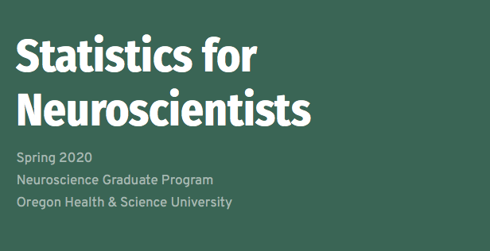

### NEUS 643: Stats for Neuroscientists

course

python

Course that applies statistics and machine learning using image processing.

Apr 1, 2020

Ted Laderas

[figure not shown]

### Ready for R

course

free

R

Get started with R/RStudio and the `tidyverse`

Mar 20, 2020

Ted Laderas, Aaron Coyner

### A Practical Guide to Reproducible Papers

workshop

biodata-club

free

reproducibility

Guidelines on making your project reproducible by others. Includes a short tour of mybinder.org.

Feb 20, 2020

Ted Laderas, Aurora Blucher

### Data Scavenger Hunt: NHANES

Jan 25, 2019

Ted Laderas

### Data Scavenger Hunt: Exploring NHANES

workshop

free

R

shiny

A short workshop teaching exploratory data analysis using the NHANES dataset.

Jan 25, 2019

Ted Laderas, Jessica Minnier, Thomas Frohwein

[figure not shown]

### R Bootcamp

self-learning

free

tidyverse

Our free online interactive course teaching the `tidyverse`.

Jan 20, 2019

Ted Laderas, Jessica Minnier

### HPC Tutorial

free

workshop

hpc

Self paced tutorial for learning about cluster computing and SLURM.

Jun 22, 2017

Ted Laderas